# Part II - Prosper Loan Data Exploration and Analysis

## by (Thiresh Lodaya)

## Investigation Overview

- Factor to affecting ProsperRating
- Factor to identify a default on loan
- major features default on credit and a good rated loan payee features

## Dataset Overview

The Dataset contains 113937 loans with 81 characteristics of those loan. The dataset contains many numerical and categorical features to explore on visual assesing on the .csv file.The dataset contains 84853 loan listing cleaned from 113937 from data of Proster Company.The dataset contains most numeric data, but also categorial data and datetime object as well.

## Preliminary Wrangling

- Monthly income is spread over wide range so having many outliers which are identified using z-score and threshold method. Wrangling of these feature is required.
- The column containing the categories(numeric) values need cleaning and reducing the number of required categories and we see in the plot there are very few categories of loan borrowers with huge reasons
- My focus of interest lies in 'Completed', 'Defaulted', 'Chargedoff' these three LoanStatus.

[figure not shown]

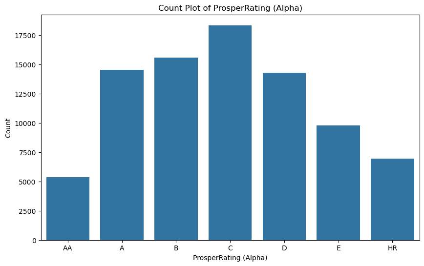

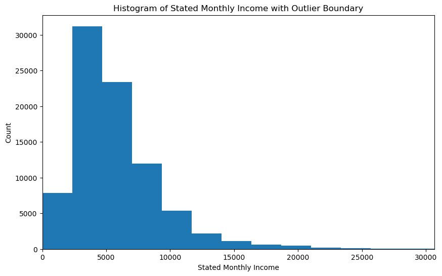

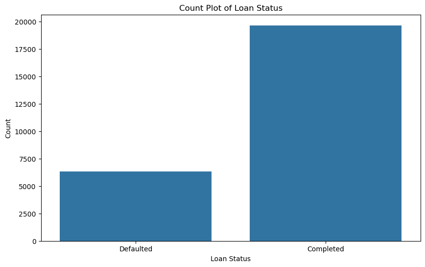

## Bivariate Exploration

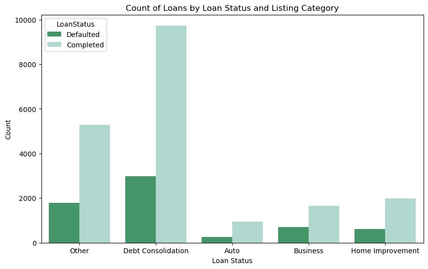

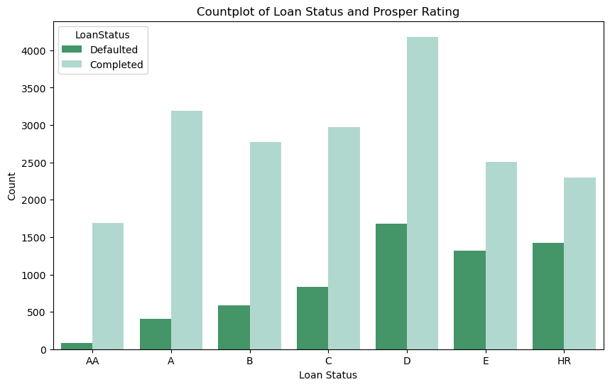

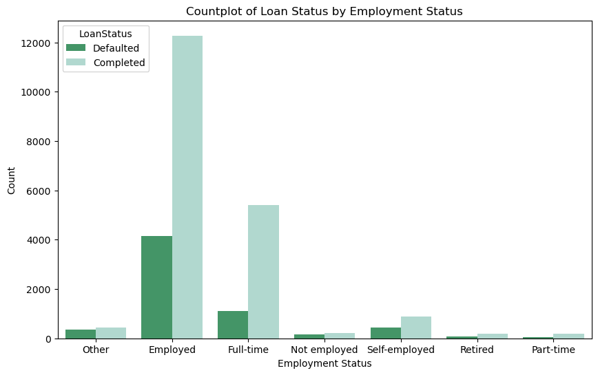

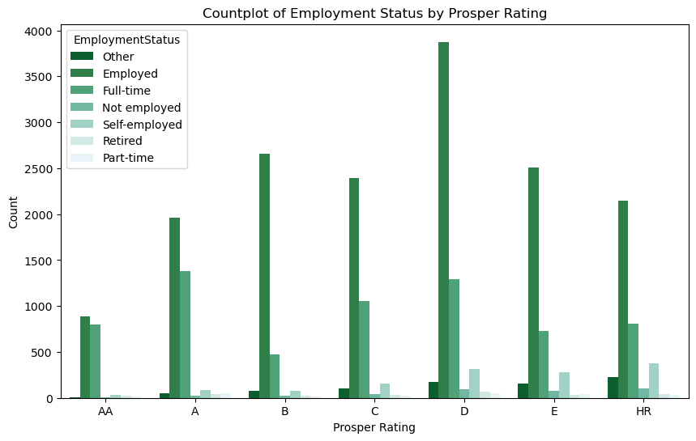

## Multivariavte Exploration

- Borrowers with higher Prosper ratings ('AA', 'A', and 'B') tend to receive larger loan amounts, while those with lower ratings ('C', 'D', 'E', and 'HR') are associated with smaller loan amounts. But amount is of defaulted is more than completed.

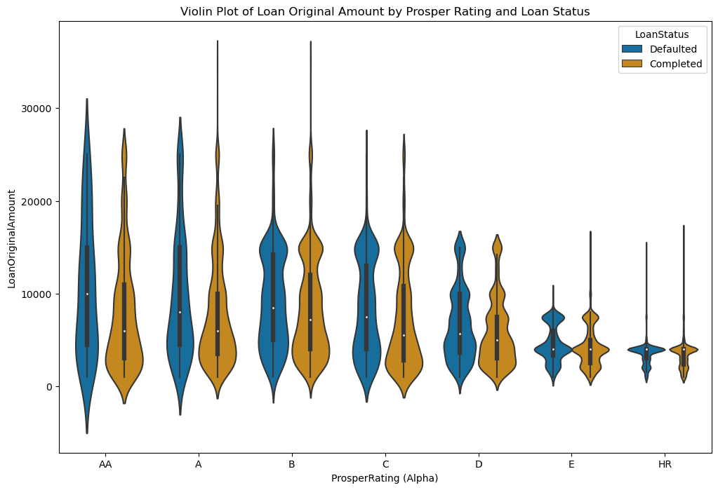

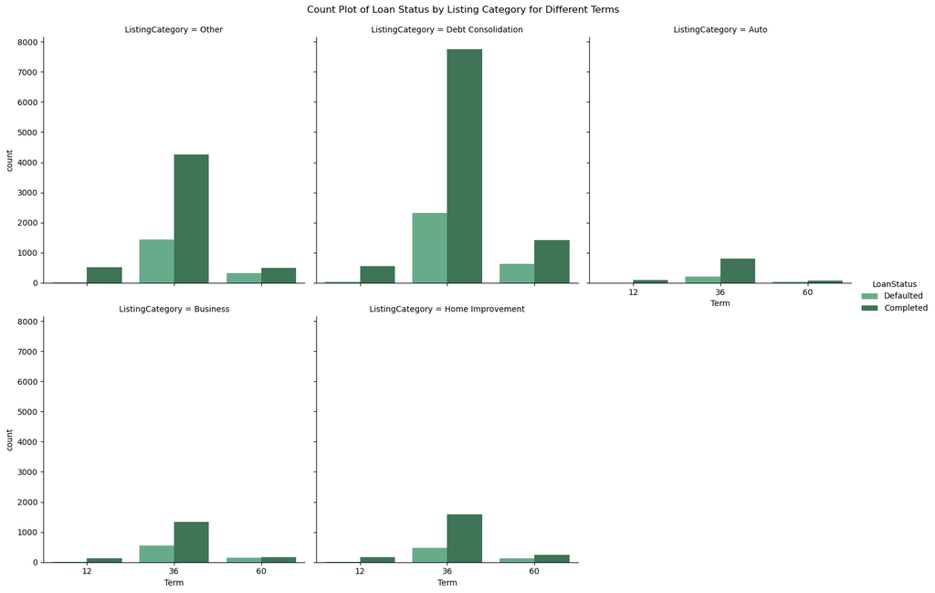